# Workshop 2: Spatial Econometrics & Road Networks

- Show All Code
- Hide All Code
- View Source

Does location matter? Spatial patterns, road access, and urban regression

Author

Jem Marie Nario

## Overview

In Workshop 1, we mapped rent values and human capital across Metro Manila. We treated each city as an **independent** observation — as if Makati and Mandaluyong had nothing to do with each other.

But cities are not islands. What happens in one city often spills over into its neighbours. **Spatial econometrics** gives us tools to detect and model these spillovers.

By the end of this workshop, you will be able to:

**Note**

## 1 · Setup

### 1.1 Install and load packages

```r
# install.packages(c("spdep", "spatialreg", "osmextract", "dodgr",
#                    "sf", "ggplot2", "dplyr", "ggrepel",
#                    "scales", "viridis", "patchwork", "geodata"))

library(tidyverse)
library(sf)
library(geodata)
library(spdep)       # spatial weights and Moran's I
library(spatialreg)  # spatial lag and error models
library(osmextract)  # download OpenStreetMap data via Geofabrik
library(dodgr)       # road network distances
library(ggplot2)
library(ggrepel)
library(scales)
library(viridis)
library(patchwork)
```

### 1.2 Load the data from Workshop 1

We reuse the same NCR city dataset and shapefile from Workshop 1.

```r
load("data/ncr_city_training.RData")   # loads 'ncr_city'

# Rebuild the shapefile and join — same steps as Workshop 1
ph_adm2    <- gadm(country = "PHL", level = 2, path = "data/")
ph_adm2_sf <- st_as_sf(ph_adm2)

ncr_sf <- ph_adm2_sf %>%
  filter(NAME_1 == "Metropolitan Manila") %>%
  mutate(city = case_when(
    NAME_2 == "Las Piñas"     ~ "Las Pinas",
    NAME_2 == "Parañaque"     ~ "Paranaque",
    NAME_2 == "Kalookan City" ~ "Caloocan",
    NAME_2 == "Makati City"   ~ "Makati",
    NAME_2 == "Pasay City"    ~ "Pasay",
    NAME_2 == "Pasig City"    ~ "Pasig",
    TRUE                      ~ NAME_2
  ))

ncr_map <- ncr_sf %>%
  left_join(ncr_city, by = "city")

ncr_centroids <- ncr_map %>%
  st_centroid() %>%
  mutate(
    lon = st_coordinates(.)[, 1],
    lat = st_coordinates(.)[, 2]
  )

cat("Cities loaded:", nrow(ncr_map), "\n")
```

```
Cities loaded: 17
```

## 2 · What Is Spatial Autocorrelation?

### 2.1 The core idea

When we run a regression in standard economics, we assume our observations are **independent** of each other. This is often reasonable for households — but it is usually *wrong* for cities.

Cities that are next to each other tend to be **similar**:

- A high-rent city is usually surrounded by other high-rent cities
- Workers commute across city borders, so wages spill over
- Infrastructure (roads, trains) links nearby cities together

This tendency for nearby places to look alike is called **spatial autocorrelation**. Ignoring it can bias our regression results.

**Note**

**Tobler’s First Law of Geography**  
*“Everything is related to everything else, but near things are more related than distant things.”*  
— Waldo Tobler (1970)

This is the founding principle of spatial econometrics.

### 2.2 Positive vs negative autocorrelation

| Pattern | What it looks like | Metro Manila example |
| --- | --- | --- |
| **Positive** | High values cluster with high; low with low | High-rent cities (Makati, BGC area) cluster together |
| **Negative** | High values border low values (checkerboard) | Rare in urban rent data |
| **None (random)** | No spatial pattern | What standard OLS assumes |

## 3 · Building a Spatial Weights Matrix

To measure spatial relationships, we need to define which cities are **neighbours**. This is captured in a **spatial weights matrix** W.

### 3.1 Queen contiguity

The simplest rule: two cities are neighbours if they **share a border or a corner** (like a queen in chess).

```r
# Build queen contiguity neighbours
ncr_nb <- poly2nb(ncr_map, queen = TRUE)

# Convert to a weights list (row-standardised)
# row-standardised means each row sums to 1
ncr_w <- nb2listw(ncr_nb, style = "W")

# Summary
summary(ncr_nb)
```

```
Neighbour list object:
Number of regions: 17
Number of nonzero links: 72
Percentage nonzero weights: 24.91349
Average number of links: 4.235294
Link number distribution:

2 3 4 5 6 7
2 6 2 2 3 2
2 least connected regions:
2 7 with 2 links
2 most connected regions:
6 14 with 7 links
```

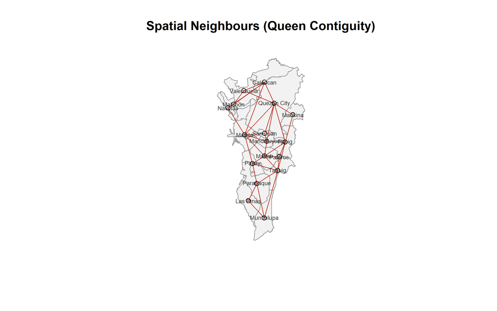

Queen contiguity neighbours — NCR cities

```r
# Extract centroid coordinates for plotting the neighbour links
coords <- st_coordinates(st_centroid(ncr_map))

plot(st_geometry(ncr_map), border = "grey60", col = "grey95",
     main = "Spatial Neighbours (Queen Contiguity)")
plot(ncr_nb, coords, add = TRUE, col = "#c0392b", lwd = 1.2)
text(coords, labels = ncr_map$city, cex = 0.55, col = "grey20")
```

**Tip**

**Reading the neighbour plot**  
Each red line connects two cities that are treated as neighbours in our spatial model. Makati, which is centrally located and small, will have many neighbours. Peripheral cities like Las Pinas or Valenzuela will have fewer.

## 4 · Moran’s I — Testing for Spatial Autocorrelation

**Moran’s I** is the standard statistic for detecting spatial autocorrelation. Think of it as the spatial version of a correlation coefficient.

| Moran’s I value | Interpretation |
| --- | --- |
| Close to **+1** | Strong positive autocorrelation (clustering) |
| Close to **0** | No spatial pattern (random) |
| Close to **−1** | Negative autocorrelation (checkerboard) |

### 4.1 Moran’s I for rent

```r
moran_rent <- moran.test(ncr_map$mean_rentval, ncr_w)
moran_rent
```

```
    Moran I test under randomisation

data:  ncr_map$mean_rentval
weights: ncr_w

Moran I statistic standard deviate = 1.8639, p-value = 0.03116
alternative hypothesis: greater
sample estimates:
Moran I statistic       Expectation          Variance
       0.19842972       -0.06250000        0.01959651
```

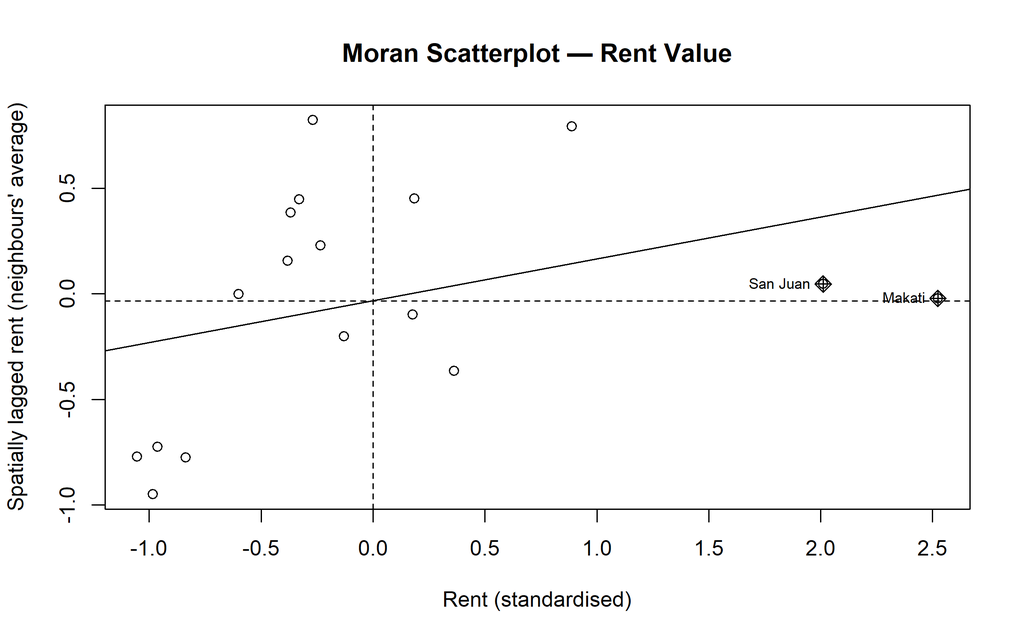

Moran scatterplot — mean rent value

```r
# The Moran scatterplot shows spatially lagged rent (y) vs own rent (x)
# A positive slope = positive spatial autocorrelation
moran.plot(
  as.vector(scale(ncr_map$mean_rentval)),
  ncr_w,
  labels  = ncr_map$city,
  xlab    = "Rent (standardised)",
  ylab    = "Spatially lagged rent (neighbours' average)",
  main    = "Moran Scatterplot — Rent Value"
)
```

```r
# Identify the LH quadrant cities (potential gentrification pressure)
z <- as.vector(scale(ncr_map$mean_rentval))
lag_z <- lag.listw(ncr_w, z)

ncr_map %>%
  st_drop_geometry() %>%
  mutate(z = z, lag_z = lag_z) %>%
  filter(z < 0, lag_z > 0) %>%
  select(city, mean_rentval, z, lag_z) %>%
  arrange(desc(lag_z))
```

```
         city mean_rentval          z     lag_z
1     Pateros     68223.88 -0.2678746 0.8248386
2       Pasay     66199.26 -0.3298379 0.4481061
3      Manila     64937.35 -0.3684587 0.3851978
4      Taguig     69318.26 -0.2343815 0.2302812
5 Quezon City     64523.58 -0.3811219 0.1563807
```

**Important**

**Interpreting the Moran scatterplot**  
The x-axis is each city’s own standardised rent. The y-axis is the *average rent of its neighbours*. A positive slope confirms that high-rent cities tend to be surrounded by other high-rent cities.

The four quadrants tell you:

- **Top-right (HH):** high rent, high-rent neighbours → hot spots
- **Bottom-left (LL):** low rent, low-rent neighbours → cold spots
- **Top-left (LH):** low rent but high-rent neighbours → potential gentrification pressure
- **Bottom-right (HL):** high rent but low-rent neighbours → isolated islands

In our NCR data, **Makati and San Juan** fall in the HL quadrant — they have the highest own rent but their neighbours’ average is near zero, making them isolated high-rent islands rather than centres of a broader high-rent cluster. The LH quadrant is more policy-relevant: **Pateros, Pasay, Manila, Taguig, and Quezon City** all have below-average rent yet sit next to relatively expensive neighbours. These cities face the classic gentrification pressure — rising land values spilling in from adjacent areas without a corresponding rise in local incomes.

### 4.2 Moran’s I for college graduation

```r
moran_college <- moran.test(ncr_map$pct_college_grad, ncr_w)
moran_college
```

```
    Moran I test under randomisation

data:  ncr_map$pct_college_grad
weights: ncr_w

Moran I statistic standard deviate = 3.7265, p-value = 9.71e-05
alternative hypothesis: greater
sample estimates:
Moran I statistic       Expectation          Variance
       0.49255748       -0.06250000        0.02218627
```

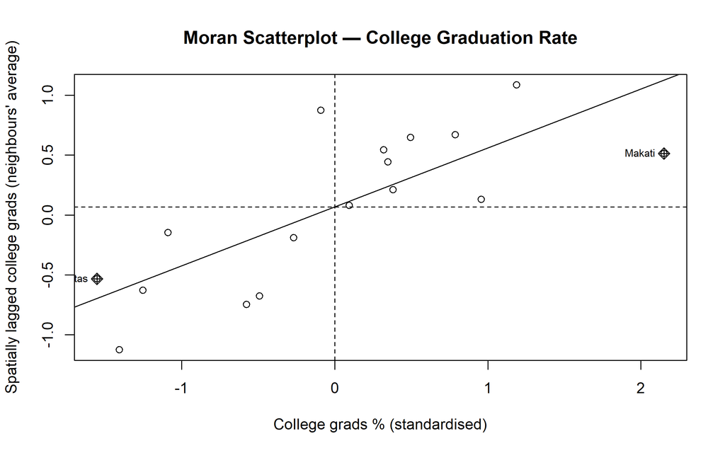

Moran scatterplot — college graduation rate

```r
moran.plot(
  as.vector(scale(ncr_map$pct_college_grad)),
  ncr_w,
  labels = ncr_map$city,
  xlab   = "College grads % (standardised)",
  ylab   = "Spatially lagged college grads (neighbours' average)",
  main   = "Moran Scatterplot — College Graduation Rate"
)
```

```r
z_col   <- as.vector(scale(ncr_map$pct_college_grad))
lag_col <- lag.listw(ncr_w, z_col)

ncr_map %>%
  st_drop_geometry() %>%
  mutate(z = z_col, lag_z = lag_col) %>%
  filter(z < 0, lag_z > 0) %>%
  select(city, pct_college_grad, z, lag_z) %>%
  arrange(desc(lag_z))
```

```
         city pct_college_grad           z     lag_z
1 Mandaluyong         16.85556 -0.09003245 0.8747108
```

**Important**

**Interpreting the Moran scatterplot**  
The x-axis is each city’s own standardised college graduation rate. The y-axis is the *average graduation rate of its neighbours*. A positive slope confirms that high-education cities cluster together spatially.

The four quadrants tell you:

- **Top-right (HH):** high education, high-education neighbours → knowledge clusters
- **Bottom-left (LL):** low education, low-education neighbours → persistent skills gaps
- **Top-left (LH):** low education but high-education neighbours → spillover potential
- **Bottom-right (HL):** high education but low-education neighbours → isolated skills hubs

Only **Mandaluyong** falls in the LH quadrant — it has a slightly below-average college graduation rate yet sits next to high-education neighbours (Makati, San Juan, Pasig). This makes it the most likely candidate for human capital spillovers: workers and firms in Mandaluyong benefit from proximity to a highly skilled labour pool without the city itself having produced those graduates locally.

So far we have used straight-line distance from Makati CBD. But people do not travel in straight lines — they use roads. In this section, we download the actual Metro Manila road network from **OpenStreetMap (OSM)**.

### 5.1 What is OpenStreetMap?

OpenStreetMap (OSM) is a free, community-built map of the world — similar to Google Maps but open and downloadable. The `osmextract` package downloads pre-built OSM extracts from Geofabrik — a mirror that packages OSM data by country — directly into R as an `sf` object. This is faster and more reliable than querying the live Overpass API.

### 5.2 Download the road network

**Warning**

**First run downloads ~30–80MB from Geofabrik.** This takes 1–2 minutes once, then saves to `data/roads_ncr.gpkg`. Every subsequent render reads from disk in under 5 seconds — no internet connection required after that.

```r
if (!file.exists("data/roads_ncr.gpkg")) {
  ph_roads <- oe_get(
    "Philippines",
    layer              = "lines",
    query              = "SELECT * FROM lines WHERE highway IN
                         ('motorway','trunk','primary','secondary','tertiary')",
    download_directory = "data/"
  )

  bbox_ncr <- st_bbox(
    c(xmin = 120.92, ymin = 14.38, xmax = 121.10, ymax = 14.76),
    crs = st_crs(4326)
  ) %>% st_as_sfc()

  roads <- ph_roads[st_intersects(ph_roads, bbox_ncr, sparse = FALSE), ]
  st_write(roads, "data/roads_ncr.gpkg", delete_dsn = TRUE)
} else {
  roads <- st_read("data/roads_ncr.gpkg")
}
cat("Road segments loaded:", nrow(roads), "\n")
```

```
Road segments loaded: 17690
```

### 5.3 Visualise the road network

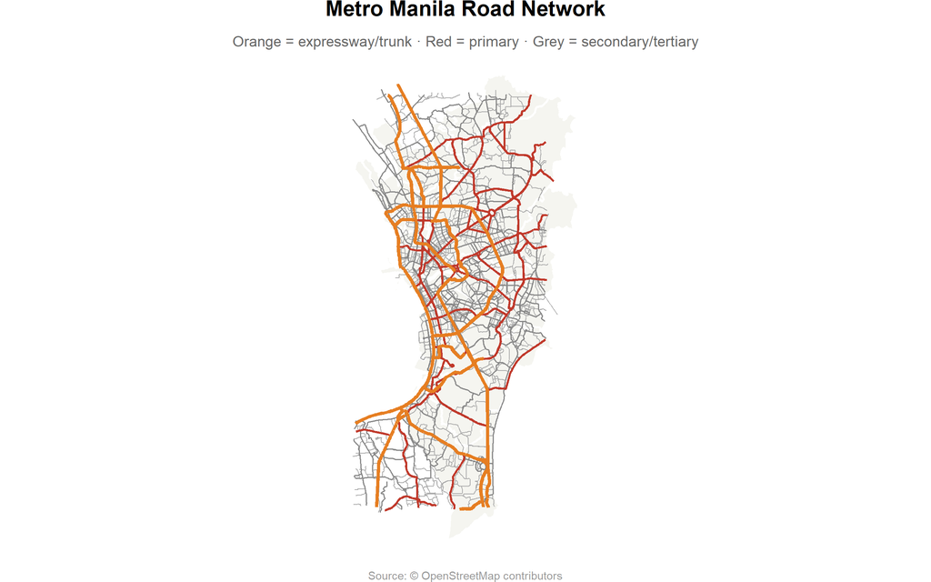

Metro Manila road network by road type (OSM)

```r
# Classify road type for styling
roads <- roads %>%
  mutate(road_class = case_when(
    highway %in% c("motorway", "trunk") ~ "Expressway / Trunk",
    highway == "primary"                ~ "Primary",
    highway == "secondary"              ~ "Secondary",
    highway == "tertiary"               ~ "Tertiary",
    TRUE                                ~ "Other"
  ))

ggplot() +
  geom_sf(data = ncr_map, fill = "#f5f5f0", color = "white",
          linewidth = 0.6) +
  geom_sf(data = filter(roads, road_class == "Other"),
          color = "#cccccc", linewidth = 0.15, alpha = 0.6) +
  geom_sf(data = filter(roads, road_class == "Tertiary"),
          color = "#aaaaaa", linewidth = 0.25) +
  geom_sf(data = filter(roads, road_class == "Secondary"),
          color = "#888888", linewidth = 0.4) +
  geom_sf(data = filter(roads, road_class == "Primary"),
          color = "#c0392b", linewidth = 0.65) +
  geom_sf(data = filter(roads, road_class == "Expressway / Trunk"),
          color = "#e67e22", linewidth = 0.9) +
  labs(
    title   = "Metro Manila Road Network",
    subtitle = "Orange = expressway/trunk · Red = primary · Grey = secondary/tertiary",
    caption = "Source: © OpenStreetMap contributors"
  ) +
  theme_void(base_size = 11) +
  theme(
    plot.title    = element_text(face = "bold", hjust = 0.5,
                                 margin = margin(b = 4)),
    plot.subtitle = element_text(hjust = 0.5, color = "grey40", size = 9),
    plot.caption  = element_text(color = "grey60", size = 7, hjust = 0.5)
  )
```

## 6 · Road Network Accessibility with `dodgr`

Straight-line distance from Makati CBD (our `dist_cbd_km` variable) ignores road layout. A city 5 km away by air may be 12 km by road if there is a river or a wall in between.

`dodgr` (**D**istances **O**n **D**irected **G**raphs in **R**) computes actual travel distances along a road network.

### 6.1 Build the road graph

```r
# dodgr needs OSM data as a data frame — weight_streetnet() converts it
road_graph <- weight_streetnet(
  roads,
  wt_profile = "motorcar"   # weight by car travel time
)

cat("Road graph edges:", nrow(road_graph), "\n")
```

```
Road graph edges: 172356
```

### 6.2 Define origin and destination points

```r
# Origin: each city centroid
origins <- ncr_centroids %>%
  st_transform(4326) %>%             # ensure WGS84
  select(city, lon, lat) %>%
  st_drop_geometry()

# Destination: Makati CBD (Ayala Avenue area)
makati_cbd <- data.frame(
  lon = 121.0244,
  lat = 14.5547
)
```

### 6.3 Compute road distances

```r
# dodgr_dists() returns a matrix of distances in metres
# from each origin to each destination
dist_matrix <- dodgr_dists(
  graph = road_graph,
  from  = as.matrix(origins[, c("lon", "lat")]),
  to    = as.matrix(makati_cbd)
)

# Attach road distance (km) back to city data
origins$road_dist_km <- as.numeric(dist_matrix) / 1000

ncr_city <- ncr_city %>%
  left_join(select(origins, city, road_dist_km), by = "city")

cat("Road distances computed. Preview:\n")
```

```
Road distances computed. Preview:
```

```r
origins %>%
  arrange(road_dist_km) %>%
  select(city, road_dist_km) %>%
  print()
```

```
          city road_dist_km
1       Makati     1.198290
2  Mandaluyong     4.138945
3        Pasay     5.468157
4     San Juan     6.563489
5      Pateros     6.819887
6       Manila     8.171533
7       Taguig     8.860493
8        Pasig     9.606967
9    Paranaque    11.802477
10   Las Pinas    16.412737
11    Marikina    16.599370
12     Malabon    17.388609
13 Quezon City    17.621858
14     Navotas    17.995415
15  Muntinlupa    20.511418
16  Valenzuela    20.742581
17    Caloocan    23.321346
```

### 6.4 Compare road vs straight-line distance

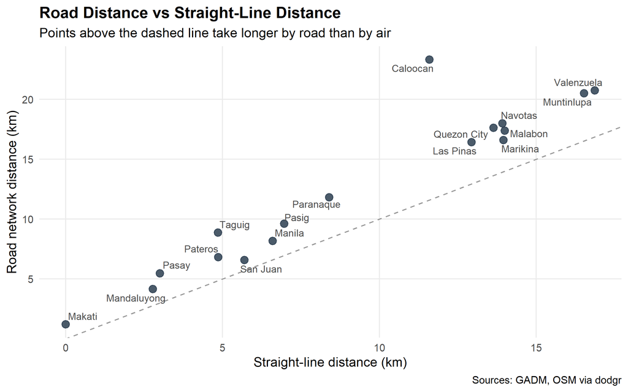

Road distance vs straight-line distance to Makati CBD

```r
# Remove road_dist_km if it already exists to avoid duplicate columns
ncr_city <- ncr_city %>% select(-any_of("road_dist_km"))

ncr_city <- ncr_city %>%
  left_join(select(origins, city, road_dist_km), by = "city")

ggplot(ncr_city, aes(x = dist_cbd_km, y = road_dist_km)) +
  geom_abline(slope = 1, intercept = 0,
              linetype = "dashed", color = "grey60") +
  geom_point(color = "#2c3e50", size = 3, alpha = 0.85) +
  geom_text_repel(aes(label = city), size = 3.2, color = "grey30",
                  max.overlaps = 20) +
  labs(
    title    = "Road Distance vs Straight-Line Distance",
    subtitle = "Points above the dashed line take longer by road than by air",
    x        = "Straight-line distance (km)",
    y        = "Road network distance (km)",
    caption  = "Sources: GADM, OSM via dodgr"
  ) +
  theme_minimal(base_size = 12) +
  theme(
    plot.title       = element_text(face = "bold"),
    panel.grid.minor = element_blank()
  )
```

**Tip**

**Reading this chart**  
The dashed line is the 45° line — it shows where road distance equals straight-line distance. Every city falls *above* this line (roads are always longer than the crow flies). Cities furthest above the line have the worst road connectivity relative to their geographic position.

The most striking outlier is **Caloocan** — it sits about 11 km from Makati by air but requires over 23 km by road, the largest gap in NCR. This reflects the barrier effect of Quezon City’s layout and the lack of direct north-south expressways through the inner city. **Valenzuela and Muntinlupa** also show large gaps, both being peripheral cities where the road network routes traffic around rather than through the urban core. At the other end, **Mandaluyong and San Juan** sit close to the 45° line — their road distance is nearly equal to straight-line distance, meaning they are exceptionally well-connected relative to their position. This plot is a simple but powerful illustration of why straight-line distance is a poor proxy for market access in a city shaped by rivers, rail lines, and unplanned road layouts.

### 6.5 Map road accessibility

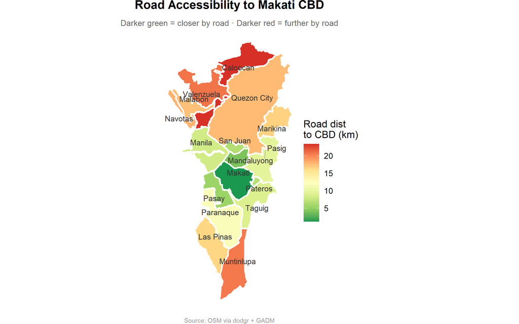

Road network distance to Makati CBD (km) — NCR cities

```r
ncr_map <- ncr_map %>%
  left_join(select(ncr_city, city, road_dist_km), by = "city")

ncr_centroids <- ncr_centroids %>%
  left_join(select(ncr_city, city, road_dist_km), by = "city")

ggplot(ncr_map) +
  geom_sf(aes(fill = road_dist_km), color = "white", linewidth = 0.8) +
  geom_text_repel(
    data          = ncr_centroids,
    aes(x = lon, y = lat, label = city),
    size          = 3,
    color         = "grey20",
    max.overlaps  = 20,
    segment.size  = 0.3,
    segment.color = "grey60"
  ) +
  scale_fill_distiller(
    palette   = "RdYlGn",
    direction = -1,
    name      = "Road dist\nto CBD (km)"
  ) +
  labs(
    title   = "Road Accessibility to Makati CBD",
    subtitle = "Darker green = closer by road · Darker red = further by road",
    caption  = "Source: OSM via dodgr + GADM"
  ) +
  theme_void(base_size = 11) +
  theme(
    plot.title    = element_text(face = "bold", hjust = 0.5,
                                 margin = margin(b = 4)),
    plot.subtitle = element_text(hjust = 0.5, color = "grey40", size = 9),
    plot.caption  = element_text(color = "grey60", size = 7, hjust = 0.5),
    legend.position = "right"
  )
```

## 7 · Spatial Regression Models

We now have three things:

1. **An outcome** — mean rent value (`mean_rentval`)
2. **An explanatory variable** — road distance to CBD (`road_dist_km`)
3. **A spatial weights matrix** — who is neighbours with whom (`ncr_w`)

Let’s put these together and see whether spatial spillovers matter.

### 7.1 Step 1 — Baseline OLS

Start with a standard regression, ignoring spatial structure:

```r
ols <- lm(log(mean_rentval) ~ road_dist_km + pct_college_grad,
          data = ncr_map)
summary(ols)
```

```
Call:
lm(formula = log(mean_rentval) ~ road_dist_km + pct_college_grad,
    data = ncr_map)

Residuals:
     Min       1Q   Median       3Q      Max
-0.38653 -0.15224 -0.03673  0.14425  0.39345

Coefficients:
                 Estimate Std. Error t value Pr(>|t|)
(Intercept)       9.95032    0.87545  11.366 1.87e-08 ***
road_dist_km     -0.01721    0.01490  -1.155   0.2673
pct_college_grad  0.08468    0.04204   2.014   0.0636 .
---
Signif. codes:  0 '***' 0.001 '**' 0.01 '*' 0.05 '.' 0.1 ' ' 1

Residual standard error: 0.2423 on 14 degrees of freedom
Multiple R-squared:  0.6375,    Adjusted R-squared:  0.5858
F-statistic: 12.31 on 2 and 14 DF,  p-value: 0.0008218
```

**Note**

**Why log(rent)?**  
Taking the log of rent makes the model multiplicative: a 1 km increase in road distance changes rent by a *percentage* rather than a fixed peso amount. This is the standard approach in urban economics (the Alonso–Muth–Mills gradient).

### 7.2 Step 2 — Test residuals for spatial autocorrelation

After running OLS, we test whether the *errors* are spatially correlated. If they are, OLS gives us biased standard errors.

```r
# Moran's I on OLS residuals
moran_resid <- lm.morantest(ols, ncr_w)
moran_resid
```

```
    Global Moran I for regression residuals

data:
model: lm(formula = log(mean_rentval) ~ road_dist_km +
pct_college_grad, data = ncr_map)
weights: ncr_w

Moran I statistic standard deviate = 1.5111, p-value = 0.06539
alternative hypothesis: greater
sample estimates:
Observed Moran I      Expectation         Variance
      0.10388793      -0.11294004       0.02059025
```

**Important**

**Decision rule**  
If the p-value from `lm.morantest()` is below 0.05, the OLS residuals are spatially autocorrelated → OLS is not appropriate → use a spatial model.

The Moran’s I on the OLS residuals is 0.104 with a p-value of 0.065. This is a borderline result — it does not clear the conventional 0.05 threshold, so we cannot firmly reject the null of no spatial autocorrelation in the residuals. However, with only 17 observations (NCR cities), the test has very low statistical power, meaning genuine spatial structure can easily go undetected. The positive Moran’s I value still suggests a tendency for residuals to cluster spatially, so it is worth proceeding with the spatial models as a robustness check rather than treating OLS as definitively adequate.

### 7.3 Step 3 — Lagrange Multiplier tests

Before choosing between a spatial lag or spatial error model, run the **LM tests**. They tell you which specification fits better.

```r
lm_tests <- lm.RStests(ols, ncr_w, test = "all")
summary(lm_tests)
```

```
    Rao's score (a.k.a Lagrange multiplier) diagnostics for spatial
    dependence
data:
model: lm(formula = log(mean_rentval) ~ road_dist_km +
pct_college_grad, data = ncr_map)
test weights: ncr_w

         statistic parameter p.value
RSerr     0.360194         1  0.5484
RSlag     0.016618         1  0.8974
adjRSerr  1.695131         1  0.1929
adjRSlag  1.351554         1  0.2450
SARMA     1.711749         2  0.4249
```

| Test | Significant? | Suggests |
| --- | --- | --- |
| **RSlag** | Yes | Spatial lag model (neighbours’ rent affects own rent) |
| **RSerr** | Yes | Spatial error model (unobserved factors cluster spatially) |
| **adjRSlag** | Yes, adjRSerr No | Prefer spatial lag |
| **adjRSerr** | Yes, adjRSlag No | Prefer spatial error |

None of the tests are statistically significant — all p-values are well above 0.05. This is consistent with the borderline residual Moran’s I result: with only 17 cities, the data do not provide strong enough evidence to formally prefer either a spatial lag or spatial error specification over OLS. We proceed with both spatial models as robustness checks rather than as corrections to a confirmed misspecification. In practice, this is a common situation in city-level analysis with small n — the spatial models are still worth estimating and comparing via AIC, but the results should be interpreted cautiously.

### 7.4 Step 4 — Spatial lag model

The **spatial lag model** adds the *average rent of neighbouring cities* as an explanatory variable:

$$\ln(\text{rent}_i) = \alpha + \rho \sum_j w_{ij} \ln(\text{rent}_j) + \beta_1 \cdot \text{road\_dist}_i + \beta_2 \cdot \text{college}_i + \varepsilon_i$$

The new term $\rho \sum_j w_{ij} \ln(\text{rent}_j)$ is the **spatial lag** — it captures how much of city *i*’s rent is explained by its neighbours’ rents.

```r
slag <- lagsarlm(
  log(mean_rentval) ~ road_dist_km + pct_college_grad,
  data   = ncr_map,
  listw  = ncr_w
)
summary(slag)
```

```
Call:lagsarlm(formula = log(mean_rentval) ~ road_dist_km + pct_college_grad,
    data = ncr_map, listw = ncr_w)

Residuals:
      Min        1Q    Median        3Q       Max
-0.381263 -0.156461 -0.031308  0.146463  0.389682

Type: lag
Coefficients: (asymptotic standard errors)
                  Estimate Std. Error z value Pr(>|z|)
(Intercept)      10.380590   3.185043  3.2592 0.001117
road_dist_km     -0.017760   0.014057 -1.2634 0.206462
pct_college_grad  0.086169   0.039558  2.1783 0.029384

Rho: -0.040181, LR test value: 0.018147, p-value: 0.89284
Asymptotic standard error: 0.28723
    z-value: -0.13989, p-value: 0.88874
Wald statistic: 0.01957, p-value: 0.88874

Log likelihood: 1.633688 for lag model
ML residual variance (sigma squared): 0.048294, (sigma: 0.21976)
Number of observations: 17
Number of parameters estimated: 5
AIC: 6.7326, (AIC for lm: 4.7508)
LM test for residual autocorrelation
test value: 1.5916, p-value: 0.2071
```

The spatial lag model gives three key results. First, **rho (ρ) = −0.04** with a p-value of 0.89 — the spatial lag term is essentially zero and far from significant. Neighbours’ rent does not predict own rent once road distance and college graduation are controlled for. Second, **college graduation remains significant** (p = 0.029): a one percentage point increase in college graduates is associated with roughly 8.6% higher rent. Third, **road distance is not significant** (p = 0.21), though the negative sign is in the expected direction.

Crucially, the **AIC of the spatial lag model (6.73) is higher than OLS (4.75)** — adding the spatial lag term made the model fit *worse*, not better. This is consistent with the insignificant LM tests: there is no meaningful spatial lag structure in this data at the city level.

### 7.5 Step 5 — Spatial error model

As an alternative, the **spatial error model** allows unobserved factors (e.g. shared infrastructure, regional policy) to cluster spatially:

$$\ln(\text{rent}_i) = \alpha + \beta_1 \cdot \text{road\_dist}_i + \beta_2 \cdot \text{college}_i + u_i$$
$$u_i = \lambda \sum_j w_{ij} u_j + \varepsilon_i$$

```r
serr <- errorsarlm(
  log(mean_rentval) ~ road_dist_km + pct_college_grad,
  data  = ncr_map,
  listw = ncr_w
)
summary(serr)
```

```
Call:errorsarlm(formula = log(mean_rentval) ~ road_dist_km + pct_college_grad,
    data = ncr_map, listw = ncr_w)

Residuals:
      Min        1Q    Median        3Q       Max
-0.398238 -0.127453 -0.060078  0.149155  0.378324

Type: error
Coefficients: (asymptotic standard errors)
                  Estimate Std. Error z value Pr(>|z|)
(Intercept)       9.894926   0.773272 12.7962  < 2e-16
road_dist_km     -0.017329   0.013525 -1.2813  0.20009
pct_college_grad  0.088673   0.037519  2.3634  0.01811

Lambda: 0.29387, LR test value: 0.5387, p-value: 0.46297
Asymptotic standard error: 0.29007
    z-value: 1.0131, p-value: 0.311
Wald statistic: 1.0264, p-value: 0.311

Log likelihood: 1.893962 for error model
ML residual variance (sigma squared): 0.045828, (sigma: 0.21408)
Number of observations: 17
Number of parameters estimated: 5
AIC: 6.2121, (AIC for lm: 4.7508)
```

The spatial error model tells a similar story. **Lambda (λ) = 0.29** with a p-value of 0.31 — the spatial error term is positive (nearby cities share unobserved characteristics) but not statistically significant. **College graduation remains significant** (p = 0.018) with a slightly larger coefficient than in the lag model: a one percentage point increase in college graduates is associated with about 8.9% higher rent. Road distance again falls short of significance (p = 0.20).

The **AIC of the spatial error model (6.21) is also higher than OLS (4.75)**, confirming that adding spatial structure does not improve fit.

### 7.6 Compare models

```r
# AIC comparison — lower AIC = better fit
tibble(
  Model = c("OLS", "Spatial Lag", "Spatial Error"),
  AIC   = c(AIC(ols), AIC(slag), AIC(serr)),
  `Spatial ρ or λ` = c(NA,
                        slag$rho,
                        serr$lambda)
) %>%
  mutate(across(where(is.numeric), ~ round(.x, 3))) %>%
  knitr::kable(caption = "Model fit comparison")
```

Model fit comparison

| Model | AIC | Spatial ρ or λ |
| --- | --- | --- |
| OLS | 4.751 | NA |
| Spatial Lag | 6.733 | -0.040 |
| Spatial Error | 6.212 | 0.294 |

**Note**

**Choosing a model**  
Pick the spatial model with the lower AIC. If both spatial models have substantially lower AIC than OLS, spatial structure matters. The coefficient on `road_dist_km` should be interpreted as the *direct* effect of road access on rent, holding neighbours’ rents constant.

OLS has the lowest AIC of the three models, confirming that spatial dependence does not meaningfully improve fit for this dataset. The spatial lag’s **ρ = −0.04** is negligible — neighbours’ rent adds nothing once the covariates are controlled for. The spatial error’s **λ = 0.29** is larger and positive, hinting that unobserved factors (shared infrastructure, policy environment) do cluster spatially across NCR cities, but not strongly enough to justify the additional parameter given only 17 observations.

## 8 · Mapping Residuals

Even after adding spatial terms, it is good practice to map the residuals. Persistent spatial clusters in the residuals suggest we are still missing an important variable.

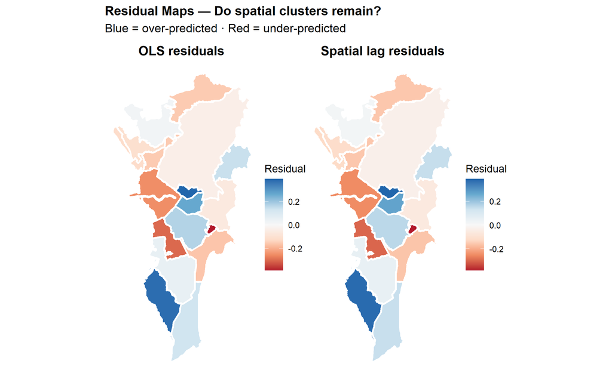

OLS vs spatial lag model residuals — NCR cities

```r
ncr_map <- ncr_map %>%
  mutate(
    resid_ols  = residuals(ols),
    resid_slag = residuals(slag)
  )

p_ols_resid <- ggplot(ncr_map) +
  geom_sf(aes(fill = resid_ols), color = "white", linewidth = 0.8) +
  scale_fill_distiller(palette = "RdBu", direction = 1,
                       name = "Residual") +
  labs(title = "OLS residuals") +
  theme_void(base_size = 10) +
  theme(plot.title = element_text(face = "bold", hjust = 0.5))

p_slag_resid <- ggplot(ncr_map) +
  geom_sf(aes(fill = resid_slag), color = "white", linewidth = 0.8) +
  scale_fill_distiller(palette = "RdBu", direction = 1,
                       name = "Residual") +
  labs(title = "Spatial lag residuals") +
  theme_void(base_size = 10) +
  theme(plot.title = element_text(face = "bold", hjust = 0.5))

p_ols_resid + p_slag_resid +
  plot_annotation(
    title   = "Residual Maps — Do spatial clusters remain?",
    subtitle = "Blue = over-predicted · Red = under-predicted",
    theme   = theme(plot.title = element_text(face = "bold", size = 12))
  )
```

**Tip**

**What to look for**  
If the OLS residual map shows obvious colour clusters (e.g. all southern cities are red), the spatial lag model should reduce that clustering. If the spatial lag map looks more random (no clear pattern), the model has successfully absorbed the spatial spillovers.